```python
!pip install -U pip
!pip install -U setuptools wheel
!pip install -U "mxnet<2.0.0" bokeh==2.0.1
!pip install autogluon --no-cache-dir
```

[output not shown]

[output cut: 167 more lines]

[output not shown]

# **Setup Kaggle API Key**

```python
# create the .kaggle directory and an empty kaggle.json file
!mkdir -p /root/.kaggle
!touch /root/.kaggle/kaggle.json
!chmod 600 /root/.kaggle/kaggle.json
```

```python
# Fill in your user name and key from creating the kaggle account and API token file
import json
kaggle_username = "idrisskc"
kaggle_key = "d790869e0eabdc467ef1796f6644b290"

# Save API token the kaggle.json file
with open("/root/.kaggle/kaggle.json", "w") as f:
    f.write(json.dumps({"username": kaggle_username, "key": kaggle_key}))
```

## **Download and explore dataset**

```python
# Download the dataset, it will be in a .zip file so you'll need to unzip it as well.
!kaggle competitions download -c bike-sharing-demand
# If you already downloaded it you can use the -o command to overwrite the file
!unzip -o bike-sharing-demand.zip
```

```python
import pandas as pd
from autogluon.tabular import TabularPredictor
```

```python
# Create the train dataset in pandas by reading the csv
# Set the parsing of the datetime column so you can use some of the `dt` features in pandas later
train = pd.read_csv('train.csv', parse_dates=['datetime'])
print("Train dataset head:")
train.head()
```

```
Train dataset head:
```

|  | datetime | season | holiday | workingday | weather | temp | atemp | humidity | windspeed | casual | registered | count |
| --- | --- | --- | --- | --- | --- | --- | --- | --- | --- | --- | --- | --- |
| 0 | 2011-01-01 00:00:00 | 1 | 0 | 0 | 1 | 9.84 | 14.395 | 81 | 0.0 | 3 | 13 | 16 |
| 1 | 2011-01-01 01:00:00 | 1 | 0 | 0 | 1 | 9.02 | 13.635 | 80 | 0.0 | 8 | 32 | 40 |
| 2 | 2011-01-01 02:00:00 | 1 | 0 | 0 | 1 | 9.02 | 13.635 | 80 | 0.0 | 5 | 27 | 32 |
| 3 | 2011-01-01 03:00:00 | 1 | 0 | 0 | 1 | 9.84 | 14.395 | 75 | 0.0 | 3 | 10 | 13 |
| 4 | 2011-01-01 04:00:00 | 1 | 0 | 0 | 1 | 9.84 | 14.395 | 75 | 0.0 | 0 | 1 | 1 |

```python
# Simple output of the train dataset to view some of the min/max/varition of the dataset features.
train.describe()
```

|  | datetime | season | holiday | workingday | weather | temp | atemp | humidity | windspeed | casual | registered | count |
| --- | --- | --- | --- | --- | --- | --- | --- | --- | --- | --- | --- | --- |
| count | 10886 | 10886.000000 | 10886.000000 | 10886.000000 | 10886.000000 | 10886.00000 | 10886.000000 | 10886.000000 | 10886.000000 | 10886.000000 | 10886.000000 | 10886.000000 |
| mean | 2011-12-27 05:56:22.399411968 | 2.506614 | 0.028569 | 0.680875 | 1.418427 | 20.23086 | 23.655084 | 61.886460 | 12.799395 | 36.021955 | 155.552177 | 191.574132 |
| min | 2011-01-01 00:00:00 | 1.000000 | 0.000000 | 0.000000 | 1.000000 | 0.82000 | 0.760000 | 0.000000 | 0.000000 | 0.000000 | 0.000000 | 1.000000 |
| 25% | 2011-07-02 07:15:00 | 2.000000 | 0.000000 | 0.000000 | 1.000000 | 13.94000 | 16.665000 | 47.000000 | 7.001500 | 4.000000 | 36.000000 | 42.000000 |
| 50% | 2012-01-01 20:30:00 | 3.000000 | 0.000000 | 1.000000 | 1.000000 | 20.50000 | 24.240000 | 62.000000 | 12.998000 | 17.000000 | 118.000000 | 145.000000 |
| 75% | 2012-07-01 12:45:00 | 4.000000 | 0.000000 | 1.000000 | 2.000000 | 26.24000 | 31.060000 | 77.000000 | 16.997900 | 49.000000 | 222.000000 | 284.000000 |
| max | 2012-12-19 23:00:00 | 4.000000 | 1.000000 | 1.000000 | 4.000000 | 41.00000 | 45.455000 | 100.000000 | 56.996900 | 367.000000 | 886.000000 | 977.000000 |
| std | NaN | 1.116174 | 0.166599 | 0.466159 | 0.633839 | 7.79159 | 8.474601 | 19.245033 | 8.164537 | 49.960477 | 151.039033 | 181.144454 |

```python
# Create the test pandas dataframe in pandas by reading the csv, remember to parse the datetime!
test = pd.read_csv('test.csv', parse_dates=['datetime'])
print("Test dataset head:")
test.head()
```

```
Test dataset head:
```

|  | datetime | season | holiday | workingday | weather | temp | atemp | humidity | windspeed |
| --- | --- | --- | --- | --- | --- | --- | --- | --- | --- |
| 0 | 2011-01-20 00:00:00 | 1 | 0 | 1 | 1 | 10.66 | 11.365 | 56 | 26.0027 |
| 1 | 2011-01-20 01:00:00 | 1 | 0 | 1 | 1 | 10.66 | 13.635 | 56 | 0.0000 |
| 2 | 2011-01-20 02:00:00 | 1 | 0 | 1 | 1 | 10.66 | 13.635 | 56 | 0.0000 |
| 3 | 2011-01-20 03:00:00 | 1 | 0 | 1 | 1 | 10.66 | 12.880 | 56 | 11.0014 |
| 4 | 2011-01-20 04:00:00 | 1 | 0 | 1 | 1 | 10.66 | 12.880 | 56 | 11.0014 |

```python
# Same thing as train and test dataset
submission = pd.read_csv("sampleSubmission.csv")
print("Submission dataset head:")
submission.head()
```

```
Submission dataset head:
```

|  | datetime | count |
| --- | --- | --- |
| 0 | 2011-01-20 00:00:00 | 0 |
| 1 | 2011-01-20 01:00:00 | 0 |
| 2 | 2011-01-20 02:00:00 | 0 |
| 3 | 2011-01-20 03:00:00 | 0 |
| 4 | 2011-01-20 04:00:00 | 0 |

## Step 3: Train a model using AutoGluon’s Tabular Prediction

Requirements:

- We are prediting `count`, so it is the label we are setting.
- Ignore `casual` and `registered` columns as they are also not present in the test dataset.
- Use the `root_mean_squared_error` as the metric to use for evaluation.
- Set a time limit of 10 minutes (600 seconds).
- Use the preset `best_quality` to focus on creating the best model.

```python
# Set label, ignored columns, metric, time limit, and preset
predictor = TabularPredictor(
    label="count",
    eval_metric="root_mean_squared_error",
    learner_kwargs={"ignored_columns": ["casual", "registered"]},
)

# Fit the model on the training data (train
predictor.fit(train_data=train,
      time_limit=600,# 10 minutes
      presets="best_quality",)
```

```
No path specified. Models will be saved in: "AutogluonModels/ag-20240428_115953"
Presets specified: ['best_quality']
Setting dynamic_stacking from 'auto' to True. Reason: Enable dynamic_stacking when use_bag_holdout is disabled. (use_bag_holdout=False)
Stack configuration (auto_stack=True): num_stack_levels=1, num_bag_folds=8, num_bag_sets=1
Dynamic stacking is enabled (dynamic_stacking=True). AutoGluon will try to determine whether the input data is affected by stacked overfitting and enable or disable stacking as a consequence.
Detecting stacked overfitting by sub-fitting AutoGluon on the input data. That is, copies of AutoGluon will be sub-fit on subset(s) of the data. Then, the holdout validation data is used to detect stacked overfitting.
Sub-fit(s) time limit is: 600 seconds.
Starting holdout-based sub-fit for dynamic stacking. Context path is: AutogluonModels/ag-20240428_115953/ds_sub_fit/sub_fit_ho.
Running the sub-fit in a ray process to avoid memory leakage.
Spend 227 seconds for the sub-fit(s) during dynamic stacking.
Time left for full fit of AutoGluon: 373 seconds.
Starting full fit now with num_stack_levels 1.
Beginning AutoGluon training ... Time limit = 373s
AutoGluon will save models to "AutogluonModels/ag-20240428_115953"
=================== System Info ===================
AutoGluon Version:  1.1.0
Python Version:     3.10.13
Operating System:   Linux
Platform Machine:   x86_64
Platform Version:   #1 SMP Tue Dec 19 13:14:11 UTC 2023
CPU Count:          4
Memory Avail:       28.86 GB / 31.36 GB (92.0%)
Disk Space Avail:   19.38 GB / 19.52 GB (99.3%)
===================================================
Train Data Rows:    10886
Train Data Columns: 11
Label Column:       count
Problem Type:       regression
Preprocessing data ...
Using Feature Generators to preprocess the data ...
Dropping user-specified ignored columns: ['casual', 'registered']
Fitting AutoMLPipelineFeatureGenerator...
	Available Memory:                    29557.26 MB
	Train Data (Original)  Memory Usage: 0.75 MB (0.0% of available memory)
	Inferring data type of each feature based on column values. Set feature_metadata_in to manually specify special dtypes of the features.
	Stage 1 Generators:
		Fitting AsTypeFeatureGenerator...
			Note: Converting 2 features to boolean dtype as they only contain 2 unique values.
	Stage 2 Generators:
		Fitting FillNaFeatureGenerator...
```

[output cut: 105 more lines]

```
	-60.2605	 = Validation score   (-root_mean_squared_error)
	83.01s	 = Training   runtime
	15.54s	 = Validation runtime
Fitting model: LightGBM_BAG_L2 ... Training model for up to 22.46s of the 22.38s of remaining time.
	Fitting 8 child models (S1F1 - S1F8) | Fitting with ParallelLocalFoldFittingStrategy (4 workers, per: cpus=1, gpus=0, memory=0.04%)
	-54.9584	 = Validation score   (-root_mean_squared_error)
	22.11s	 = Training   runtime
	0.72s	 = Validation runtime
Fitting model: WeightedEnsemble_L3 ... Training model for up to 360.0s of the -4.81s of remaining time.
	Ensemble Weights: {'LightGBM_BAG_L2': 0.882, 'LightGBMXT_BAG_L2': 0.118}
	-54.8589	 = Validation score   (-root_mean_squared_error)
	0.05s	 = Training   runtime
	0.0s	 = Validation runtime
AutoGluon training complete, total runtime = 377.9s ... Best model: "WeightedEnsemble_L3"
TabularPredictor saved. To load, use: predictor = TabularPredictor.load("AutogluonModels/ag-20240428_115953")
```

```
<autogluon.tabular.predictor.predictor.TabularPredictor at 0x7cf88618f280>
```

### Review AutoGluon's training run with ranking of models that did the best.

```
AutoGluon Training Summary
*** Summary of fit() ***
Estimated performance of each model:
                     model   score_val              eval_metric  pred_time_val    fit_time  pred_time_val_marginal  fit_time_marginal  stack_level  can_infer  fit_order
0      WeightedEnsemble_L3  -54.858936  root_mean_squared_error      55.182612  333.077298                0.001136           0.048197            3       True         11
1          LightGBM_BAG_L2  -54.958376  root_mean_squared_error      39.646068  250.015402                0.723933          22.105142            2       True         10
2        LightGBMXT_BAG_L2  -60.260533  root_mean_squared_error      54.457544  310.923959               15.535408          83.013699            2       True          9
3    KNeighborsDist_BAG_L1  -84.169493  root_mean_squared_error       0.096034    0.050252                0.096034           0.050252            1       True          2
4      WeightedEnsemble_L2  -84.169493  root_mean_squared_error       0.097108    0.096614                0.001075           0.046362            2       True          8
5    KNeighborsUnif_BAG_L1 -101.632965  root_mean_squared_error       0.067638    0.409128                0.067638           0.409128            1       True          1
6   RandomForestMSE_BAG_L1 -116.548359  root_mean_squared_error       0.717591    8.436251                0.717591           8.436251            1       True          5
7     ExtraTreesMSE_BAG_L1 -124.600676  root_mean_squared_error       0.684933    4.480533                0.684933           4.480533            1       True          7
8          CatBoost_BAG_L1 -130.856043  root_mean_squared_error       0.139215   73.346108                0.139215          73.346108            1       True          6
9          LightGBM_BAG_L1 -131.054162  root_mean_squared_error       4.945429   30.733736                4.945429          30.733736            1       True          4
10       LightGBMXT_BAG_L1 -131.460909  root_mean_squared_error      32.271296  110.454252               32.271296         110.454252            1       True          3
Number of models trained: 11
Types of models trained:
{'StackerEnsembleModel_XT', 'StackerEnsembleModel_LGB', 'WeightedEnsembleModel', 'StackerEnsembleModel_CatBoost', 'StackerEnsembleModel_RF', 'StackerEnsembleModel_KNN'}
Bagging used: True  (with 8 folds)
Multi-layer stack-ensembling used: True  (with 3 levels)
Feature Metadata (Processed):
(raw dtype, special dtypes):
('float', [])                : 3 | ['temp', 'atemp', 'windspeed']
('int', [])                  : 3 | ['season', 'weather', 'humidity']
('int', ['bool'])            : 2 | ['holiday', 'workingday']
('int', ['datetime_as_int']) : 5 | ['datetime', 'datetime.year', 'datetime.month', 'datetime.day', 'datetime.dayofweek']
*** End of fit() summary ***
```

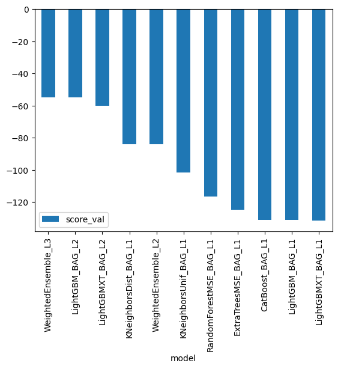

```python
print("AutoGluon Training Summary")
predictor.fit_summary()  # Shows ranking of models
predictor.leaderboard(silent=True).plot(kind="bar", x="model", y="score_val")
```

### Create predictions from test dataset

```python
predictions = predictor.predict(test)
predictions.head()
```

```
INFO:sklearnex: sklearn.neighbors.KNeighborsRegressor.predict: running accelerated version on CPU
INFO:sklearnex: sklearn.utils.validation._assert_all_finite: running accelerated version on CPU
INFO:sklearnex: sklearn.neighbors.KNeighborsRegressor.predict: running accelerated version on CPU
INFO:sklearnex: sklearn.utils.validation._assert_all_finite: running accelerated version on CPU
```

```
0    36.087788
1    45.626396
2    49.250435
3    52.941814
4    53.673512
Name: count, dtype: float32
```

#### NOTE: Kaggle will reject the submission if we don't set everything to be > 0.

```python
# Describe the `predictions` series to see if there are any negative values
print("Checking for negative predictions")
print(predictions.describe())
```

```
Checking for negative predictions
count    6493.000000
mean       99.895370
std        90.337456
min        -1.761248
25%        16.469213
50%        63.187702
75%       172.325775
max       372.841492
Name: count, dtype: float64
```

```python
# # How many negative values do we have?
negative_count = predictions[predictions < 0].count()
print(f"Number of negative predictions: {negative_count}")
# # Set negative predictions to zero
predictions[predictions < 0] = 0
predictions.describe()
```

[output not shown]

```
count    6493.000000
mean       99.895752
std        90.337029
min         0.000000
25%        16.469213
50%        63.187702
75%       172.325775
max       372.841492
Name: count, dtype: float64
```

### Set predictions to submission dataframe, save, and submit

```python
submission["count"] = predictions
submission.to_csv("submission.csv", index=False)
```

```python
!kaggle competitions submit -c bike-sharing-demand -f submission.csv -m "my first raw submission"
```

#### View submission via the command line or in the web browser under the competition's page - `My Submissions`

```python
!kaggle competitions submissions -c bike-sharing-demand | tail -n +1 | head -n 6
```

## Step 4: Exploratory Data Analysis and Creating an additional feature

- Any additional feature will do, but a great suggestion would be to separate out the datetime into hour, day, or month parts.

[figure not shown]

```python
# Create a histogram of all features to show the distribution of each one relative to the data. This is part of the exploritory data analysis
# train.hist()
import matplotlib.pyplot as plt

# Create the histogram
train.hist(bins=15, edgecolor='white')

# Adjust subplot spacing
plt.subplots_adjust(hspace=.5, wspace=.5)
plt.gcf().set_size_inches(12, 10)
# Show the histogram
plt.show()
```

```python
# create a new feature
# train["season"] = train["season"]
# test["season"] = test["season"]

# Create new features
temperature_bins = [0, 15, 25, 40]  # Adjust thresholds as needed
temperature_labels = ['Cold', 'Mild', 'Hot']
train['temp_category'] = pd.cut(train['temp'], bins=temperature_bins, labels=temperature_labels)
test['temp_category'] = pd.cut(test['temp'], bins=temperature_bins, labels=temperature_labels)

# Extract year, month, and day (correction applied)
train["year"] = train["datetime"].dt.year
train["month"] = train["datetime"].dt.month
train["day"] = train["datetime"].dt.day

test["year"] = test["datetime"].dt.year
test["month"] = test["datetime"].dt.month
test["day"] = test["datetime"].dt.day

# Function to define rush hour based on time
def define_rush_hour(hour):
  if 7 <= hour <= 9:
    return "Morning Rush"
  elif 11 <= hour <= 13:
    return "Lunch Rush"
  elif 17 <= hour <= 18:
    return "Evening Rush"
  else:
    return "Non-Rush"

# Extract hour from datetime
train["hour"] = train["datetime"].dt.hour
test["hour"] = test["datetime"].dt.hour

# Apply rush hour function
train["rush_hour"] = train["hour"].apply(define_rush_hour)
test["rush_hour"] = test["hour"].apply(define_rush_hour)

# Categorize temperature (consider adjusting categories based on your data)
temp_categories = pd.cut(train["temp"], bins=[0, 15, 30, 40], labels=["Cold", "Mild", "Hot",])
train["temp_category"] = temp_categories
test["temp_category"] = pd.cut(test["temp"], bins=[0, 15, 30, 40], labels=["Cold", "Mild", "Hot",])

# Categorize wind speed (consider adjusting categories based on your data)
wind_categories = pd.cut(train["windspeed"], bins=[0, 20, 40], labels=["Wind", "Mild Wind",])
train["wind_category"] = wind_categories
test["wind_category"] = pd.cut(test["windspeed"], bins=[0, 20, 40], labels=["Wind", "Mild Wind",])

# Categorize humidity (consider adjusting categories based on your data) - Fixed error
humidity_categories = pd.cut(train["humidity"], bins=[0, 50, 100], labels=["Low Humidity", "High Humidity",])
train["humidity_category"] = humidity_categories
test["humidity_category"] = pd.cut(test["humidity"], bins=[0, 50, 100], labels=["Low Humidity", "High Humidity",])

# Create new features from datetime
train["year"] = train["datetime"].dt.year
train["month"] = train["datetime"].dt.month
train["day"] = train["datetime"].dt.day

test["year"] = test["datetime"].dt.year
test["month"] = test["datetime"].dt.month
test["day"] = test["datetime"].dt.day
```

## Make category types for these so models know they are not just numbers

- AutoGluon originally sees these as ints, but in reality they are int representations of a category.
- Setting the dtype to category will classify these as categories in AutoGluon.

```python
# Convert season and weather to categorical data types
train["season"] = train["season"].astype("category")
train["weather"] = train["weather"].astype("category")

test["season"] = test["season"].astype("category")
test["weather"] = test["weather"].astype("category")

# View data information after type conversion
train.info()
test.info()
```

```
<class 'pandas.core.frame.DataFrame'>
RangeIndex: 10886 entries, 0 to 10885
Data columns (total 20 columns):
 #   Column             Non-Null Count  Dtype
---  ------             --------------  -----
 0   datetime           10886 non-null  datetime64[ns]
 1   season             10886 non-null  category
 2   holiday            10886 non-null  int64
 3   workingday         10886 non-null  int64
 4   weather            10886 non-null  category
 5   temp               10886 non-null  float64
 6   atemp              10886 non-null  float64
 7   humidity           10886 non-null  int64
 8   windspeed          10886 non-null  float64
 9   casual             10886 non-null  int64
```

[output cut: 36 more lines]

```python
train.head()
```

|  | datetime | season | holiday | workingday | weather | temp | atemp | humidity | windspeed | casual | registered | count | year | month | day | temp_category | hour | rush_hour | wind_category | humidity_category |
| --- | --- | --- | --- | --- | --- | --- | --- | --- | --- | --- | --- | --- | --- | --- | --- | --- | --- | --- | --- | --- |
| 0 | 2011-01-01 00:00:00 | 1 | 0 | 0 | 1 | 9.84 | 14.395 | 81 | 0.0 | 3 | 13 | 16 | 2011 | 1 | 1 | Cold | 0 | Non-Rush | NaN | High Humidity |
| 1 | 2011-01-01 01:00:00 | 1 | 0 | 0 | 1 | 9.02 | 13.635 | 80 | 0.0 | 8 | 32 | 40 | 2011 | 1 | 1 | Cold | 1 | Non-Rush | NaN | High Humidity |
| 2 | 2011-01-01 02:00:00 | 1 | 0 | 0 | 1 | 9.02 | 13.635 | 80 | 0.0 | 5 | 27 | 32 | 2011 | 1 | 1 | Cold | 2 | Non-Rush | NaN | High Humidity |
| 3 | 2011-01-01 03:00:00 | 1 | 0 | 0 | 1 | 9.84 | 14.395 | 75 | 0.0 | 3 | 10 | 13 | 2011 | 1 | 1 | Cold | 3 | Non-Rush | NaN | High Humidity |
| 4 | 2011-01-01 04:00:00 | 1 | 0 | 0 | 1 | 9.84 | 14.395 | 75 | 0.0 | 0 | 1 | 1 | 2011 | 1 | 1 | Cold | 4 | Non-Rush | NaN | High Humidity |

```python
# View are new feature
train.tail()
```

|  | datetime | season | holiday | workingday | weather | temp | atemp | humidity | windspeed | casual | registered | count | year | month | day | temp_category | hour | rush_hour | wind_category | humidity_category |
| --- | --- | --- | --- | --- | --- | --- | --- | --- | --- | --- | --- | --- | --- | --- | --- | --- | --- | --- | --- | --- |
| 10881 | 2012-12-19 19:00:00 | 4 | 0 | 1 | 1 | 15.58 | 19.695 | 50 | 26.0027 | 7 | 329 | 336 | 2012 | 12 | 19 | Mild | 19 | Non-Rush | Mild Wind | Low Humidity |
| 10882 | 2012-12-19 20:00:00 | 4 | 0 | 1 | 1 | 14.76 | 17.425 | 57 | 15.0013 | 10 | 231 | 241 | 2012 | 12 | 19 | Cold | 20 | Non-Rush | Wind | High Humidity |
| 10883 | 2012-12-19 21:00:00 | 4 | 0 | 1 | 1 | 13.94 | 15.910 | 61 | 15.0013 | 4 | 164 | 168 | 2012 | 12 | 19 | Cold | 21 | Non-Rush | Wind | High Humidity |
| 10884 | 2012-12-19 22:00:00 | 4 | 0 | 1 | 1 | 13.94 | 17.425 | 61 | 6.0032 | 12 | 117 | 129 | 2012 | 12 | 19 | Cold | 22 | Non-Rush | Wind | High Humidity |
| 10885 | 2012-12-19 23:00:00 | 4 | 0 | 1 | 1 | 13.12 | 16.665 | 66 | 8.9981 | 4 | 84 | 88 | 2012 | 12 | 19 | Cold | 23 | Non-Rush | Wind | High Humidity |

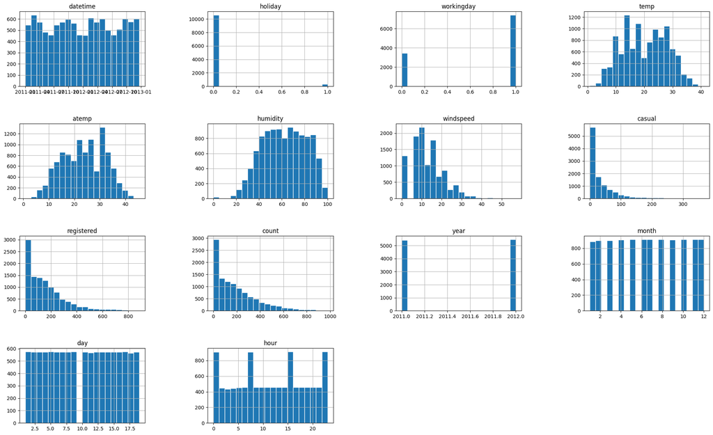

```python
# View histogram of all features again now with the hour feature
# train.hist()
import matplotlib.pyplot as plt

# Create the histogram
train.hist(bins=20, edgecolor='white')

# Adjust subplot spacing
plt.subplots_adjust(hspace=.5, wspace=.5)
plt.gcf().set_size_inches(25, 15)
# Show the histogram
plt.show()
```

```python
# Define a new predictor with new features and hyperparameter tuning options
predictor_new_features = TabularPredictor(
    label="count",
    eval_metric="root_mean_squared_error",
    learner_kwargs={"ignored_columns": ["casual", "registered"]},
)
predictor_new_features.fit(train_data=train,
      time_limit=800,  # Adjust time limit as needed
      presets="best_quality",)
```

```
No path specified. Models will be saved in: "AutogluonModels/ag-20240428_132158"
Presets specified: ['best_quality']
Setting dynamic_stacking from 'auto' to True. Reason: Enable dynamic_stacking when use_bag_holdout is disabled. (use_bag_holdout=False)
Stack configuration (auto_stack=True): num_stack_levels=1, num_bag_folds=8, num_bag_sets=1
Dynamic stacking is enabled (dynamic_stacking=True). AutoGluon will try to determine whether the input data is affected by stacked overfitting and enable or disable stacking as a consequence.
Detecting stacked overfitting by sub-fitting AutoGluon on the input data. That is, copies of AutoGluon will be sub-fit on subset(s) of the data. Then, the holdout validation data is used to detect stacked overfitting.
Sub-fit(s) time limit is: 800 seconds.
Starting holdout-based sub-fit for dynamic stacking. Context path is: AutogluonModels/ag-20240428_132158/ds_sub_fit/sub_fit_ho.
Running the sub-fit in a ray process to avoid memory leakage.
Spend 210 seconds for the sub-fit(s) during dynamic stacking.
Time left for full fit of AutoGluon: 590 seconds.
Starting full fit now with num_stack_levels 1.
Beginning AutoGluon training ... Time limit = 590s
AutoGluon will save models to "AutogluonModels/ag-20240428_132158"
=================== System Info ===================
AutoGluon Version:  1.1.0
Python Version:     3.10.13
Operating System:   Linux
Platform Machine:   x86_64
Platform Version:   #1 SMP Tue Dec 19 13:14:11 UTC 2023
CPU Count:          4
Memory Avail:       28.84 GB / 31.36 GB (92.0%)
Disk Space Avail:   18.77 GB / 19.52 GB (96.2%)
===================================================
Train Data Rows:    10886
Train Data Columns: 19
Label Column:       count
Problem Type:       regression
Preprocessing data ...
Using Feature Generators to preprocess the data ...
Dropping user-specified ignored columns: ['casual', 'registered']
Fitting AutoMLPipelineFeatureGenerator...
	Available Memory:                    29536.56 MB
	Train Data (Original)  Memory Usage: 1.49 MB (0.0% of available memory)
	Inferring data type of each feature based on column values. Set feature_metadata_in to manually specify special dtypes of the features.
	Stage 1 Generators:
		Fitting AsTypeFeatureGenerator...
			Note: Converting 3 features to boolean dtype as they only contain 2 unique values.
	Stage 2 Generators:
		Fitting FillNaFeatureGenerator...
```

[output cut: 111 more lines]

```
	-31.7904	 = Validation score   (-root_mean_squared_error)
	26.36s	 = Training   runtime
	0.83s	 = Validation runtime
Fitting model: CatBoost_BAG_L2 ... Training model for up to 64.43s of the 64.34s of remaining time.
	Fitting 8 child models (S1F1 - S1F8) | Fitting with ParallelLocalFoldFittingStrategy (4 workers, per: cpus=1, gpus=0, memory=0.06%)
	-30.9755	 = Validation score   (-root_mean_squared_error)
	56.82s	 = Training   runtime
	0.2s	 = Validation runtime
Fitting model: WeightedEnsemble_L3 ... Training model for up to 360.0s of the 2.92s of remaining time.
	Ensemble Weights: {'LightGBM_BAG_L2': 0.52, 'LightGBMXT_BAG_L2': 0.32, 'CatBoost_BAG_L2': 0.12, 'CatBoost_BAG_L1': 0.04}
	-30.1276	 = Validation score   (-root_mean_squared_error)
	0.07s	 = Training   runtime
	0.0s	 = Validation runtime
AutoGluon training complete, total runtime = 587.19s ... Best model: "WeightedEnsemble_L3"
TabularPredictor saved. To load, use: predictor = TabularPredictor.load("AutogluonModels/ag-20240428_132158")
```

```
<autogluon.tabular.predictor.predictor.TabularPredictor at 0x7cf8486163b0>
```

```
*** Summary of fit() ***
Estimated performance of each model:
                     model   score_val              eval_metric  pred_time_val    fit_time  pred_time_val_marginal  fit_time_marginal  stack_level  can_infer  fit_order
0      WeightedEnsemble_L3  -30.127587  root_mean_squared_error      70.709296  521.557517                0.001305           0.072583            3       True         14
1          LightGBM_BAG_L2  -30.468249  root_mean_squared_error      67.598608  423.725551                1.094408          31.219578            2       True         11
2        LightGBMXT_BAG_L2  -30.896831  root_mean_squared_error      69.414235  433.450242                2.910035          40.944269            2       True         10
3          CatBoost_BAG_L2  -30.975459  root_mean_squared_error      66.703548  449.321087                0.199347          56.815114            2       True         13
4   RandomForestMSE_BAG_L2  -31.790380  root_mean_squared_error      67.334525  418.869471                0.830324          26.363497            2       True         12
5      WeightedEnsemble_L2  -32.384096  root_mean_squared_error      64.960429  357.434076                0.001106           0.046372            2       True          9
6          LightGBM_BAG_L1  -33.707632  root_mean_squared_error      24.064045   98.344599               24.064045          98.344599            1       True          4
7        LightGBMXT_BAG_L1  -35.105715  root_mean_squared_error      39.765971  134.816228               39.765971         134.816228            1       True          3
8          CatBoost_BAG_L1  -35.758790  root_mean_squared_error       0.292812  113.692923                0.292812         113.692923            1       True          6
9   RandomForestMSE_BAG_L1  -38.820366  root_mean_squared_error       0.764577   10.480337                0.764577          10.480337            1       True          5
10    ExtraTreesMSE_BAG_L1  -39.103617  root_mean_squared_error       0.816329    5.456354                0.816329           5.456354            1       True          7
11  NeuralNetFastAI_BAG_L1  -72.998696  root_mean_squared_error       0.641433   29.614643                0.641433          29.614643            1       True          8
12   KNeighborsDist_BAG_L1  -84.169493  root_mean_squared_error       0.071918    0.053617                0.071918           0.053617            1       True          2
13   KNeighborsUnif_BAG_L1 -101.632965  root_mean_squared_error       0.087116    0.047273                0.087116           0.047273            1       True          1
Number of models trained: 14
Types of models trained:
{'StackerEnsembleModel_XT', 'StackerEnsembleModel_LGB', 'WeightedEnsembleModel', 'StackerEnsembleModel_CatBoost', 'StackerEnsembleModel_RF', 'StackerEnsembleModel_NNFastAiTabular', 'StackerEnsembleModel_KNN'}
Bagging used: True  (with 8 folds)
Multi-layer stack-ensembling used: True  (with 3 levels)
Feature Metadata (Processed):
(raw dtype, special dtypes):
('category', [])             : 6 | ['season', 'weather', 'temp_category', 'rush_hour', 'wind_category', ...]
('float', [])                : 3 | ['temp', 'atemp', 'windspeed']
('int', [])                  : 4 | ['humidity', 'month', 'day', 'hour']
('int', ['bool'])            : 3 | ['holiday', 'workingday', 'year']
('int', ['datetime_as_int']) : 3 | ['datetime', 'datetime.year', 'datetime.dayofweek']
*** End of fit() summary ***
```

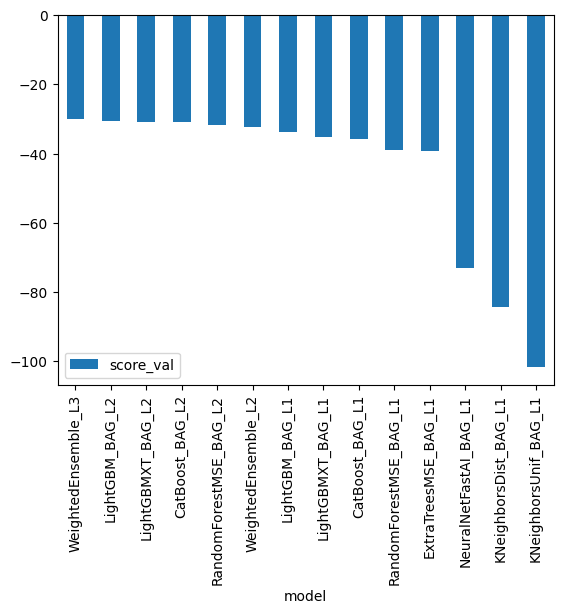

```python
predictor_new_features.fit_summary()
predictor_new_features.leaderboard(silent=True).plot(kind="bar", x="model", y="score_val")
```

```python
# Remember to set all negative values to zero
predictions_new_features =predictor_new_features.predict(test)
predictions_new_features[predictions_new_features < 0] = 0
predictions_new_features.describe()
```

```
INFO:sklearnex: sklearn.neighbors.KNeighborsRegressor.predict: running accelerated version on CPU
INFO:sklearnex: sklearn.utils.validation._assert_all_finite: running accelerated version on CPU
INFO:sklearnex: sklearn.neighbors.KNeighborsRegressor.predict: running accelerated version on CPU
INFO:sklearnex: sklearn.utils.validation._assert_all_finite: running accelerated version on CPU
```

```
count    6493.000000
mean      158.079849
std       136.425079
min         2.132181
25%        50.646919
50%       123.710052
75%       225.112473
max       793.263672
Name: count, dtype: float64
```

```python
# Same submitting predictions
submission_new_features = pd.read_csv("sampleSubmission.csv")
submission_new_features["count"] = predictions_new_features
submission_new_features.to_csv("submission_new_features.csv", index=False)
```

```python
!kaggle competitions submit -c bike-sharing-demand -f submission_new_features.csv -m "my new features_"
```

```python
!kaggle competitions submissions -c bike-sharing-demand | tail -n +1 | head -n 6
```

## Step 6: Hyper parameter optimization

- There are many options for hyper parameter optimization.
- Options are to change the AutoGluon higher level parameters or the individual model hyperparameters.
- The hyperparameters of the models themselves that are in AutoGluon. Those need the `hyperparameter` and `hyperparameter_tune_kwargs` arguments.

```python
# Define a new predictor with hyperparameter tuning
predictor_new_hpo = TabularPredictor(
    label="count",
    eval_metric="root_mean_squared_error",
    learner_kwargs={"ignored_columns": ["casual", "registered"]},
)
predictor_new_hpo.fit(train_data=train,time_limit=1000,
                      presets="best_quality",
                      hyperparameters="multimodal",
                      hyperparameter_tune_kwargs={"search_strategy": "bayesopt"},
                     )
```

```
No path specified. Models will be saved in: "AutogluonModels/ag-20240428_135916"
Presets specified: ['best_quality']
Warning: hyperparameter tuning is currently experimental and may cause the process to hang.
Setting dynamic_stacking from 'auto' to True. Reason: Enable dynamic_stacking when use_bag_holdout is disabled. (use_bag_holdout=False)
Stack configuration (auto_stack=True): num_stack_levels=1, num_bag_folds=8, num_bag_sets=1
Dynamic stacking is enabled (dynamic_stacking=True). AutoGluon will try to determine whether the input data is affected by stacked overfitting and enable or disable stacking as a consequence.
Detecting stacked overfitting by sub-fitting AutoGluon on the input data. That is, copies of AutoGluon will be sub-fit on subset(s) of the data. Then, the holdout validation data is used to detect stacked overfitting.
Sub-fit(s) time limit is: 1000 seconds.
Starting holdout-based sub-fit for dynamic stacking. Context path is: AutogluonModels/ag-20240428_135916/ds_sub_fit/sub_fit_ho.
Running the sub-fit in a ray process to avoid memory leakage.
Spend 77 seconds for the sub-fit(s) during dynamic stacking.
Time left for full fit of AutoGluon: 923 seconds.
Starting full fit now with num_stack_levels 1.
Beginning AutoGluon training ... Time limit = 923s
AutoGluon will save models to "AutogluonModels/ag-20240428_135916"
=================== System Info ===================
AutoGluon Version:  1.1.0
Python Version:     3.10.13
Operating System:   Linux
Platform Machine:   x86_64
Platform Version:   #1 SMP Tue Dec 19 13:14:11 UTC 2023
CPU Count:          4
Memory Avail:       28.83 GB / 31.36 GB (91.9%)
Disk Space Avail:   17.80 GB / 19.52 GB (91.2%)
===================================================
Train Data Rows:    10886
Train Data Columns: 19
Label Column:       count
Problem Type:       regression
Preprocessing data ...
Using Feature Generators to preprocess the data ...
Dropping user-specified ignored columns: ['casual', 'registered']
Fitting AutoMLPipelineFeatureGenerator...
	Available Memory:                    29521.71 MB
	Train Data (Original)  Memory Usage: 1.49 MB (0.0% of available memory)
	Inferring data type of each feature based on column values. Set feature_metadata_in to manually specify special dtypes of the features.
	Stage 1 Generators:
		Fitting AsTypeFeatureGenerator...
			Note: Converting 3 features to boolean dtype as they only contain 2 unique values.
	Stage 2 Generators:
```

[output cut: 200 more lines]

[output not shown]

```
<autogluon.tabular.predictor.predictor.TabularPredictor at 0x7cf8783e4fd0>
```

```
AutoGluon Training Summary (Hyperparameter Tuning)
*** Summary of fit() ***
Estimated performance of each model:
                  model  score_val              eval_metric  pred_time_val    fit_time  pred_time_val_marginal  fit_time_marginal  stack_level  can_infer  fit_order
0  LightGBMLarge_BAG_L1 -33.366176  root_mean_squared_error      10.878874   71.860279               10.878874          71.860279            1       True          1
1   WeightedEnsemble_L3 -33.366176  root_mean_squared_error      10.879757   71.878878                0.000883           0.018599            3       True          4
2   WeightedEnsemble_L2 -33.366176  root_mean_squared_error      10.879766   71.865075                0.000892           0.004796            2       True          2
3  LightGBMLarge_BAG_L2 -35.336467  root_mean_squared_error      11.701597  100.732563                0.822723          28.872284            2       True          3
Number of models trained: 4
Types of models trained:
{'StackerEnsembleModel_LGB', 'WeightedEnsembleModel'}
Bagging used: True  (with 8 folds)
Multi-layer stack-ensembling used: True  (with 3 levels)
Feature Metadata (Processed):
(raw dtype, special dtypes):
('category', [])             : 6 | ['season', 'weather', 'temp_category', 'rush_hour', 'wind_category', ...]
('float', [])                : 3 | ['temp', 'atemp', 'windspeed']
('int', [])                  : 4 | ['humidity', 'month', 'day', 'hour']
('int', ['bool'])            : 3 | ['holiday', 'workingday', 'year']
('int', ['datetime_as_int']) : 3 | ['datetime', 'datetime.year', 'datetime.dayofweek']
*** End of fit() summary ***
```

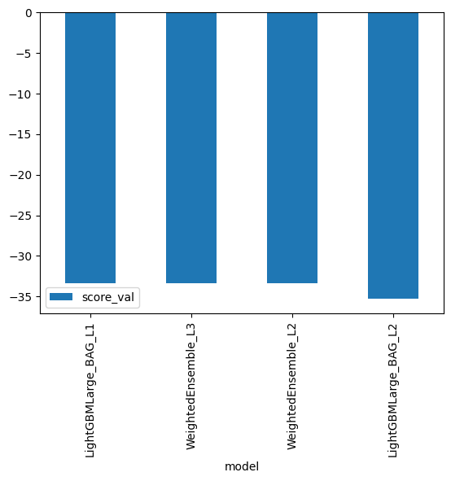

```python
print("AutoGluon Training Summary (Hyperparameter Tuning)")
predictor_new_hpo.fit_summary()
predictor_new_hpo.leaderboard(silent=True).plot(kind="bar", x="model", y="score_val")
```

```python
# Remember to set all negative values to zero
predictor_new_hpo =predictor_new_hpo.predict(test)
predictor_new_hpo[predictor_new_hpo < 0] = 0
predictor_new_hpo.describe()
```

```
count    6493.000000
mean      193.251556
std       175.078583
min         0.000000
25%        46.930218
50%       152.335068
75%       285.665466
max       900.647827
Name: count, dtype: float64
```

```python
# Same submitting predictions
submission_new_hpo = pd.read_csv("sampleSubmission.csv")
submission_new_hpo["count"] = predictor_new_hpo
submission_new_hpo.to_csv("submission_new_hpo.csv", index=False)
```

```python
!kaggle competitions submit -c bike-sharing-demand -f submission_new_hpo.csv -m "new features with hyperparameters"
```

```python
!kaggle competitions submissions -c bike-sharing-demand | tail -n +1 | head -n 6
```

```python
train.tail()
```

|  | datetime | season | holiday | workingday | weather | temp | atemp | humidity | windspeed | casual | registered | count | year | month | day | temp_category | hour | rush_hour | wind_category | humidity_category |
| --- | --- | --- | --- | --- | --- | --- | --- | --- | --- | --- | --- | --- | --- | --- | --- | --- | --- | --- | --- | --- |
| 10881 | 2012-12-19 19:00:00 | 4 | 0 | 1 | 1 | 15.58 | 19.695 | 50 | 26.0027 | 7 | 329 | 336 | 2012 | 12 | 19 | Mild | 19 | Non-Rush | Mild Wind | Low Humidity |
| 10882 | 2012-12-19 20:00:00 | 4 | 0 | 1 | 1 | 14.76 | 17.425 | 57 | 15.0013 | 10 | 231 | 241 | 2012 | 12 | 19 | Cold | 20 | Non-Rush | Wind | High Humidity |
| 10883 | 2012-12-19 21:00:00 | 4 | 0 | 1 | 1 | 13.94 | 15.910 | 61 | 15.0013 | 4 | 164 | 168 | 2012 | 12 | 19 | Cold | 21 | Non-Rush | Wind | High Humidity |
| 10884 | 2012-12-19 22:00:00 | 4 | 0 | 1 | 1 | 13.94 | 17.425 | 61 | 6.0032 | 12 | 117 | 129 | 2012 | 12 | 19 | Cold | 22 | Non-Rush | Wind | High Humidity |
| 10885 | 2012-12-19 23:00:00 | 4 | 0 | 1 | 1 | 13.12 | 16.665 | 66 | 8.9981 | 4 | 84 | 88 | 2012 | 12 | 19 | Cold | 23 | Non-Rush | Wind | High Humidity |

## Step 7: Write a Report

### Refer to the markdown file for the full report

### Creating plots and table for report

[figure not shown]

```python
# fig = pd.DataFrame(
#     {
#         "model": ["initial", "add_features", "hpo"],
#         "score": [ -141.895373, -135.718541, -172.077226]
#     }
# ).plot(x="model", y="score", figsize=(8, 6)).get_figure()
# fig.savefig('model_train_score.png')

# Sample code for visualizations (replace with your preferred methods)
import matplotlib.pyplot as plt

# Line plot comparing model training scores (example)
models = ["initial", "add_features", "hpo"]
scores = [-131.460909, -101.632965, -35.336467]  # Replace with actual scores
plt.figure(figsize=(8, 6))
plt.plot(models, scores, marker='o')
plt.xlabel("Model")
plt.ylabel("Training Score")
plt.title("Model Training Score Comparison")
plt.grid(True)
plt.savefig('model_train_score.png')  # Save the plot
```

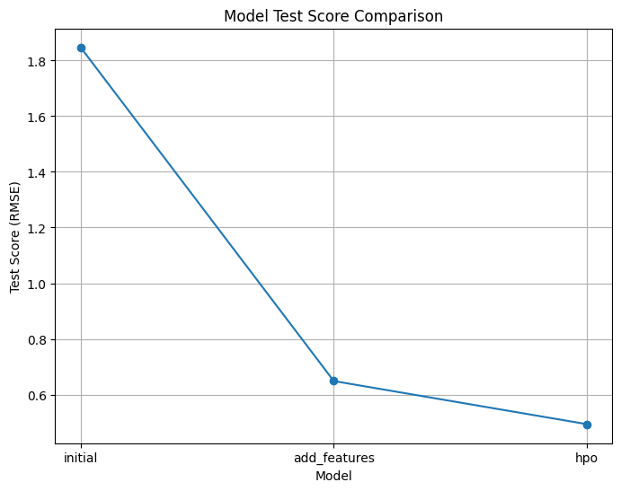

```python
# fig = pd.DataFrame(
#     {
#         "test_eval": ["initial", "add_features", "hpo"],
#         "score": [1.7988, 1.8027, 1.3385]
#     }
# ).plot(x="test_eval", y="score", figsize=(8, 6)).get_figure()
# fig.savefig('model_test_score.png')

# Similar plot for test scores (optional)
test_scores = [1.84751, 0.64893, 0.49393]  # Replace with actual test scores
plt.figure(figsize=(8, 6))
plt.plot(models, test_scores, marker='o')
plt.xlabel("Model")
plt.ylabel("Test Score (RMSE)")
plt.title("Model Test Score Comparison")
plt.grid(True)
plt.savefig('model_test_score.png')  # Save the plot
```

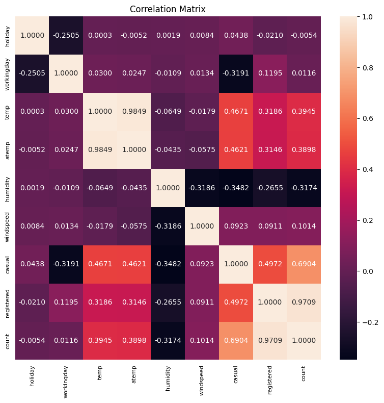

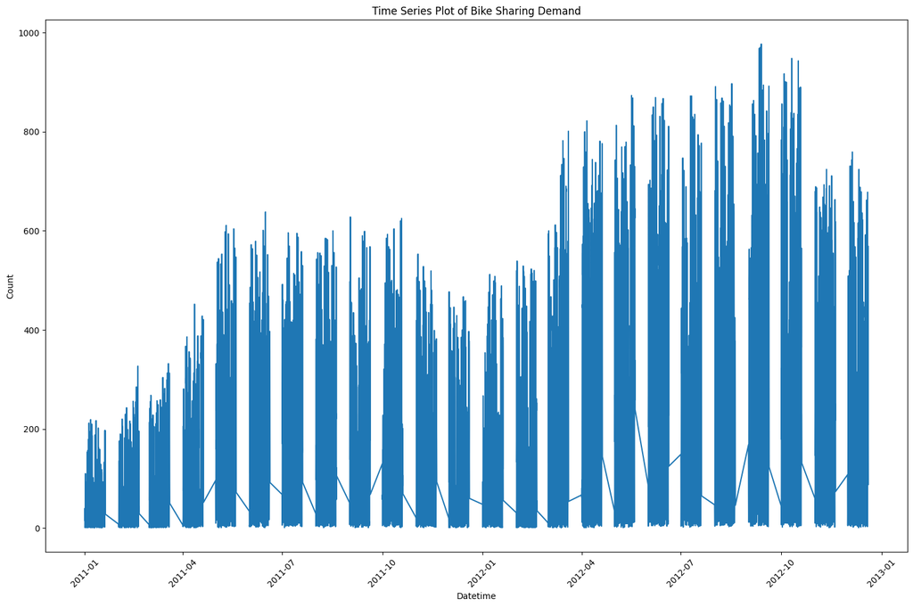

```python
# Import libraries
import seaborn as sns
import matplotlib.pyplot as plt

# Assuming you have features prepared for correlation matrix
# Exclude non-numeric columns
numeric_cols = train.select_dtypes(include=['float64', 'int64']).columns
corr = train[numeric_cols].corr()

# Plot correlation matrix
# sns.heatmap(corr, annot=True)
# plt.title("Correlation Matrix")
# plt.savefig('correlation_matrix.png')  # Save the plot

# Create a larger heatmap with improved formatting
fig, ax = plt.subplots(figsize=(8, 8))  # Increase figure size for larger heatmap
sns.heatmap(corr, annot=True, ax=ax, fmt=".4f")

ax.set_title("Correlation Matrix", fontsize=12)
ax.tick_params(bottom=False, left=False, labelsize=8)

plt.tight_layout()

# Save the plot with higher resolution
plt.savefig('correlation_matrix.png', dpi=100)

# Time series plot (optional)
plt.figure(figsize=(15, 10))
plt.plot(train["datetime"], train["count"])
plt.xlabel("Datetime")
plt.ylabel("Count")
plt.title("Time Series Plot of Bike Sharing Demand")
plt.xticks(rotation=45)  # Rotate x-axis labels for readability
plt.tight_layout()
plt.savefig('time_series_plot.png')  # Save the plot
```

### Hyperparameter table

```python
from tabulate import tabulate
# Hyperparameter table (example)
data = {
    "model": ["initial", "add_features", "hpo"],
    "hpo1": [600, 800, 1000],  # Replace with actual time limits
    "hpo2": ['default', 'default', 'multimodal'],
    "hpo3": ['default', 'default', 'bayesopt'],
    "score": [1.84751, 0.64893, 0.49393]  # Replace with actual test scores
}

df = pd.DataFrame(data)
print(tabulate(df, headers='keys', tablefmt='fancy_round'))
```

```
    model           hpo1  hpo2        hpo3        score
--  ------------  ------  ----------  --------  -------
 0  initial          600  default     default   1.84751
 1  add_features     800  default     default   0.64893
 2  hpo             1000  multimodal  bayesopt  0.49393
```